# Project Report

Samantha J. Poteet and Tavio A. Pela

2022-12-06

# Data Analytics Term Project

## Project Description

### Topic:

Risk and effects of flooding in the US

### Why it Matters:

Risk of flooding puts communities in danger of numerous short- and long-term consequences. Entire communities can be uprooted as their homes are destroyed. Flooding can cause fatalities, property damage, and disease by carrying sewage and toxic runoff, polluting drinking water supplies, and leaving bacteria and mold that contribute to respiratory illnesses in their wake. Flood risks are expected to continue to increase as global climate change contributes to heavier precipitation, more frequent hurricanes, and higher sea levels.

### Research Question and Motivation

To what extent is there disproportionate exposure to flood risk based on race and income? This is a descriptive question rather than a causal or predictive question. It is important to have a framework for identifying which populations are at greatest risk of flooding as a first step to considering where to target efforts to mitigate the impacts of flooding. Observing disparities in risk is also a first step to identifying potential inequities in how we address flood risk that should be rectified.

### Description of Datasets

#### - Race_and_Income

The Race_and_Income datasets contain information about both racial composition and median household income for 2020 at the county, census tract, and block group level.

These datasets were made by combining sections of two tables from the IPUMS National Historical Geographic Information System (IPUMS NHGIS, University of Minnesota, www.nhgis.org). We make use of Table B03002 and Table B19013. Both use data from the 2020 American Community Survey available at the county, census tract, and block group level.

Table B03002 displays estimates of population demographics categorized via Hispanic or Latino origin by race (example categories include Not Hispanic or Latino: White alone, Not Hispanic or Latino: Two or more races, Hispanic or Latino: White alone, etc.).

Table B19013 displays median household income in the past 12 months (relative to the 2020 survey period) in 2020 inflation-adjusted dollars.

#### - NFHL

Access to the National Flood Hazard Layer (NFHL) is provided by the Federal Emergency Management Agency (FEMA) (FEMA Map Service Center - National Flood Hazard Layer (NFHL) Database Search). In this dataset there are 32 layers, some include: flood hazard zones and labels, flood insurance rate map, hydraulic and flood control structures, coastal barrier resource systems and otherwise protected areas, and Limit of Moderate Wave Action (LiMWA).

For our purposes we are concerned with the zoning layers and the flood control structures. The data set is the most current and updated in 2022. This dataset spatially covers over 90 percent of the United States.

#### - How are they Related?

The NFHL observations contain identifying codes that can be used to merge it with the Race_and_Income data by census tract so that we can investigate flood hazard zone demographics.

## Data Processing

### Overview

In our project, we develop a methodology for using the Race/Income and NHFL data that should allow for tract-level analysis of any county in the US for which the data is not missing. Running our analysis across the whole of the US (or even the whole of one state at once) is possible in theory, but the computational time required to produce our results/visuals is too large given the volume of data required, so we choose narrow our focus to Broward County, FL as a test case.

We chose to start our analysis with Florida because of of its low elevation and high flood risk. From here we narrowed down our analysis to Broward County because of the County’s racial and ethnic diversity. Giving us a dataset with sufficient variation to analyze impacts across demographics.

### Race/Income Data

Our tract-level data on racial demographics includes many different categories, which we simplify for the purposes of our analysis. In our analysis, we use “White” to refer to those reported as “Not Hispanic or Latino: White alone”, “Black” to refer to those reported as “Not Hispanic or Latino: Black or African American alone”, “Native” to refer to those reported as “Not Hispanic or Latino: American Indian and Alaska Native alone”, “Asian” to refer to those reported as “Not Hispanic or Latino: Asian alone”, “Hispanic” to refer to those reported as “Hispanic or Latino”, and “Other” to refer to those in all other Not Hispanic or Latino categories (e.g., “Not Hispanic or Latino: Some other race alone”, “Not Hispanic or Latino: Two or more races”, etc.).

While this is an oversimplification of race and ethnicity in the United States (in particular because it does not draw distinctions between, say “Hispanic or Latino: White alone”, “Hispanic or Latino: Black or African American alone”, and “Hispanic or Latino: Two or more races”), we used these categories as a way of approximating broad trends in population distributions.

We have no extreme values in this data to deal with, but we are missing data for two tracts in our county of focus. The largest tract missing is a part of the Everglades National Forest, therefore there is no demographic data to report. On our maps, these areas are grayed out to show in which reasons we were missing data. The validity of the portion for which our analysis relies upon estimates made from the data is caveated as being valid only for the non missing sample.

We transform this data in a few ways for some of our visualizations.

For our bar plot of the demographics of Broward County, we use the racial categories described above and compute the sum of the population observed in each category across all tracts, as well as the total county population. We then divide the totals for each racial group by the total county population and multiply by 100 to get the percentage of the county population made up by each group.

For our map of tracts by largest ethnic group, we create a variable identifying the largest racial group in each given tract. We then subset the original dataframe so that all tracts with the same dominant racial group are each in their own dataframe. We then calculate what percentage of the total population of each tract the dominant group in that tract makes up.

Finally, for our analysis of racial disparities in risk exposure to flooding, we first make a simplifying assumption that *within* tracts, population is dispersed evenly and there are no racial disparities in risk-exposure. The effect of this assumption will likely be to bias us against finding disproportionate impacts. Combining our Race/Income data with our NHFL data and reprojecting it to a projection that conserves area, we calculate the proportion of each tract’s total area that is covered by each kind of flood zone. We then use our simplifying assumption to estimate the number of people in each category affected by each kind of flood zone. We then separate “VE” and “AE” FEMA Flood zone designations as our “high risk” areas. “VE” designation is for high risk coastal areas and “AE” designation is defined as special flood hazard areas with high risk. Finally, we compute what percent of the highest-risk population each group makes up by dividing the sum of the estimated affected population of that group by the sum of the total estimated affected population.

### NHFL Data

Using FEMA Flood Map Service Center (https://msc.fema.gov/portal/home) we download the flood data layer for Broward County, Florida. For our analysis we want to answer questions about the share of the population that impacted by which types of flood zones. To start, we do an intersection between the Broward census tracts demographics data frame and the Broward county flood zone data layer. Then to calculate the area of this new data frame we re-project using the US National Atlas Equal Area. After grouping by tract and flood zone type we are left with a data frame that gives us the area of each flood zone type within each tract.

We make the following risk level numeric ranking choices based off the following definitions of flood zone designations.

#### Definitions of FEMA Flood Zone Designations - within our sample

“VE” Coastal High Risk Category - Areas along coasts subject to inundation by the 1-percent-annual-chance flood event with additional hazards due to storm-induced velocity wave action. BFEs derived from detailed hydraulic coastal analyses are shown within these zones. Ranking 5.

“AE” Special High Risk Category - Areas subject to inundation by the 1-percent-annual-chance flood event determined by detailed methods. BFEs are shown within these zones. Ranking 4.

“AH” Special High Risk Category - Areas subject to inundation by 1-percent-annual-chance shallow flooding (usually areas of ponding) where average depths are 1–3 feet. BFEs derived from detailed hydraulic analyses are shown in this zone. Ranking 3.

“AO” Special High Risk Category - Areas subject to inundation by 1-percent-annual-chance shallow flooding (usually sheet flow on sloping terrain) where average depths are 1–3 feet. Average flood depths derived from detailed hydraulic analyses are shown within this zone. Ranking 2.

“X” Moderate and minimal risk category - Moderate risk areas within the 0.2-percent-annual-chance floodplain, areas of 1-percent-annual-chance flooding where average depths are less than 1 foot, areas of 1-percent-annual-chance flooding where the contributing drainage area is less than 1 square mile, and areas protected from the 1-percent-annual-chance flood by a levee. No BFEs or base flood depths are shown within these zones. (Zone X (shaded) is used on new and revised maps in place of Zone B). Minimal risk areas outside the 1-percent and .2-percent-annual-chance floodplains. No BFEs or base flood depths are shown within these zones. (Zone X (unshaded) is used on new and revised maps in place of Zone C). Ranking 1.

“D” Undetermined risk areas - Unstudied areas where flood hazards are undetermined, but flooding is possible. No mandatory flood insurance purchase requirements apply, but coverage is available in participating communities. Ranking 0. All definitions at (https://floodpartners.com/fema-flood-map/)

## Findings

### Hazard Flood Layer

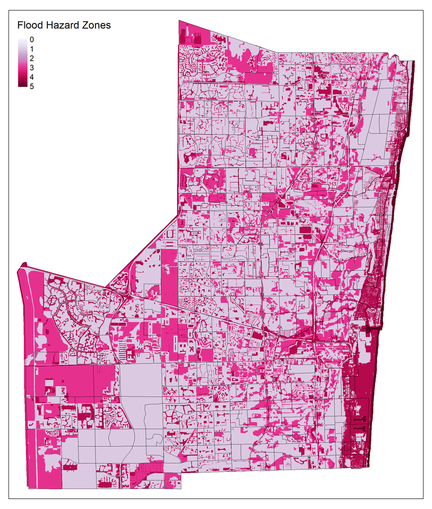

This map shows FEMA Flood Hazard Data layer with census tract borders for Broward County. The lighter the shade indicates lower flood risk and the darker the shade indicates higher flood risk. See Definitions of FEMA Flood Zone Designations for details on how numeric flood rankings were created. These flood zones are used to determine the need for flood risk insurance for property owners. We can see that the eastern border of the county is at the highest level of risk (likely because it is on the coast). Even so, small high risk zones are scattered throughout the county, and there are some larger moderately at-risk locales at the north and south -western sections of the county for which there is flood risk data.

### Median Household income by tract

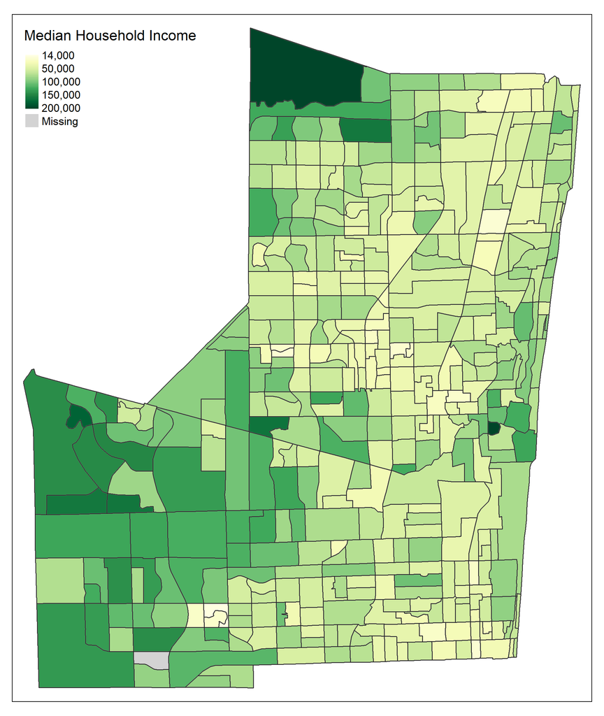

This map shows median household income by tract, acquired from 2020 census data, with the the lighter-shaded tracts representing lower income and the darker-shaded tracts representing wealthier tracts. There are 159 tracts with median household income below 52,000 (upper limit for lower-middle class). There is 87 tracts with income above 87,000 (lower limit for upper middle class). At a glance, it is hard to see a clear, consistent relationship between wealth and flood risk. The wealthiest tract is in a moderately at-risk location, as are several tracts on the higher end of the income distribution in the southwestern edge of the urban part of the county. The high-risk coastal tracts have neither the highest nor lowest median incomes in the county. Most of the lower income tracts are roughly in the center of Broward’s urban region.

#### High Flood Risk versus Income

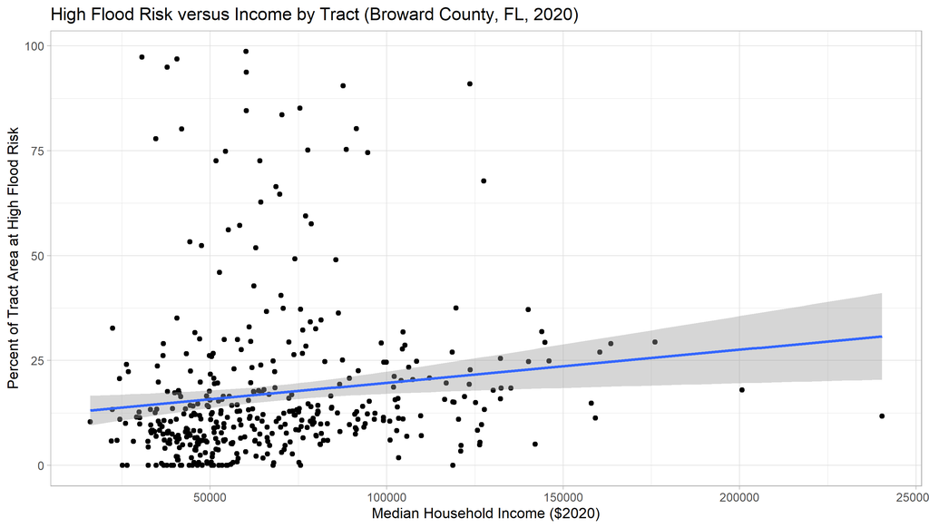

This scatter plot shows the relationship between a tract’s median household income and the percentage of that tract covered by a high-risk flood area. A line of best fit indicates there might be a positive relationship, but this should be taken with a grain of salt. The tracts with the highest proportion of high-risk area tend to fall more in the middle-class median income tracts, with the richest tracts and the poorest tracts having a relatively low proportion of high-risk area.

### Largest Racial group in tract by population

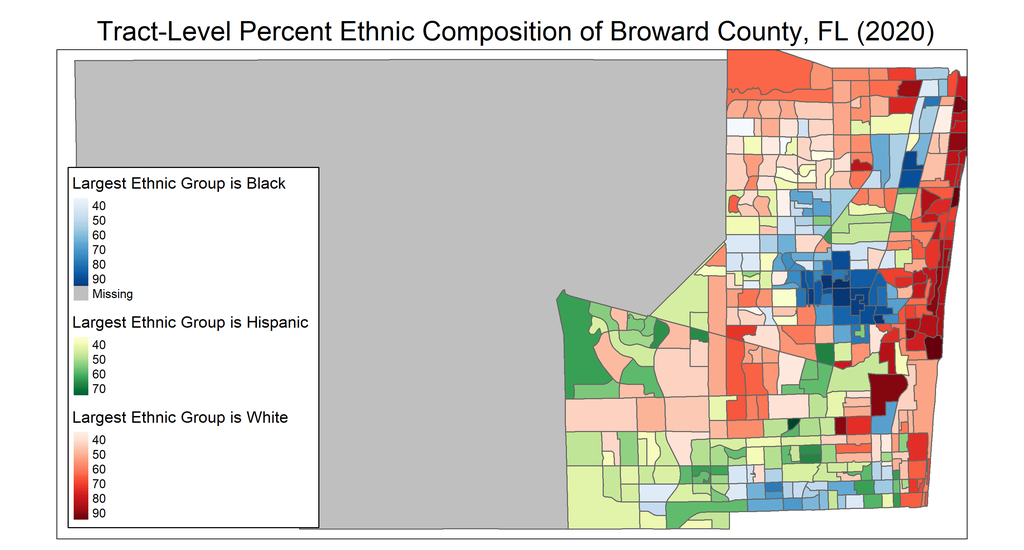

This figure displays the tracts by largest racial groups using data from the 2020 census. Notably, the coast is heavily white-dominated, while black-majority tracts are clustered most densely in the center of Broward’s urban area.

### Main Findings: Demographic Disparities in Flood Risk

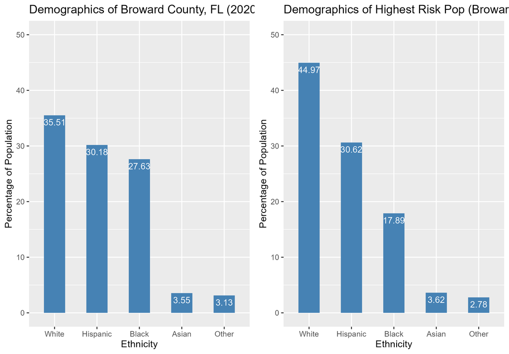

This figure shows the demographic composition of Broward county as a whole in 2020 compared to our estimates for the demographics of the county at highest risk of experiencing flooding. We can see that white people are estimated to be at disproportionately high risk, while black people are estimated to be at disproportionately low risk. This is likely due in large part to the fact that many white people live on the coast, which has the greatest concentration of high-risk flood zones, whereas many black people live in the low-risk center of Broward’s urban region.

Scatter plots showing the relationship between the percentage of a tract’s total population that is white/black and the percentage of that tract covered by a high-risk flood area corroborate these findings. We can see that a higher percentage white population is associated on average with a higher proportion of high-risk area, whereas a higher percentage black population is associated on average with a lower proportion of high-risk area.

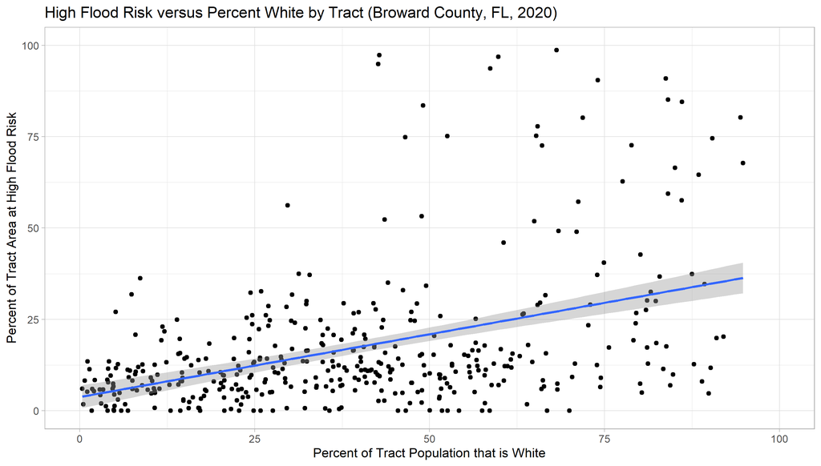

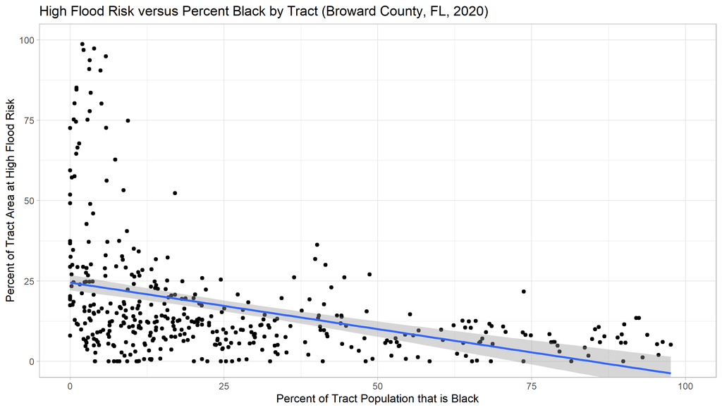

For comparison, we can look to the Hispanic group, which the bar graph does not show to be at disproportionately higher or lower risk. The scatter plot below shows no significant relationship between the percentage of a tract’s total population that is hispanic and the percentage of that tract covered by a high-risk flood area.

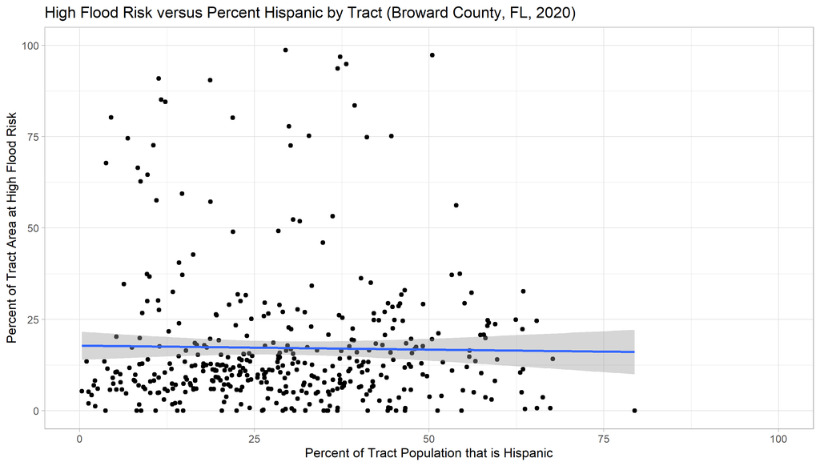

### Limitations

Our findings suffer from several limitations.

First, are missing income and demographic data for two tracts in our county of focus. The largest tract missing is a part of the Everglades National Forest, which is not expected to have much flood risk or population density, and the other tract for which we are missing data contains no high-risk zones. We thus expect our results to hold, regardless of the missing data, but should still note that we can only say with certainty that our findings are valid for the non-missing sample.

Second, we must make a large simplifying assumption when calculating estimates for high-risk demographics in Broward, namely that *within tracts*, the population is perfectly evenly dispersed, and there are no racial inequities. It may be the case, then, that due to differences in individual access to flood insurance or protective architecture, different degrees of crowded housing or intergenerational homes in different areas within-tracts, the amount in which disproportionate risk is experienced differs from our findings. Furthermore, exposure to risk is not a perfect proxy for looking at the actual damages suffered from flooding because there may be different degrees of adaptation depending on knowledge of risk and resource availability.

Finally, we should stress that we are not attaching normative or causal significance to our findings. We have not indicated whether the disparities in risk-exposure are a result of personal choice, historical happenstance, discrimination, etc. These findings and subsequent applications of our current methodology should be seen as a first step to examining county and tract-level effects of flooding. Further work to help build on their significance would be to combine our demographic data with flood insurance data, or use our median household income data to estimate flood insurance access and use it to estimate disparities in the impacts of flooding rather than simply risk exposure.

## Econometric Analysis

### Motivation

We use descriptive regression analysis to help us quantify some of the relationships we found in our exploratory analysis. The precise values of our coefficients should be taken with a grain of salt, however, as there are few variables we were able to control for using our datasets. We also want to reiterate that our results to not have a causal interpretation; these regressions area another means to corroborate the findings from our maps/graphs.

### Methods

In our first model, we look for relationships between a tract’s ethnic demographic characteristics and the percent of the tract’s area that falls within a high risk flood zone while controlling for median household income. Since there is partial multicollinearity between each of the variables for the percentage of tract population falling into a certain racial demographic, including all these variables at once would greatly inflate our standard errors, so we run each one separately first. Our results are shown in Table 1 below.

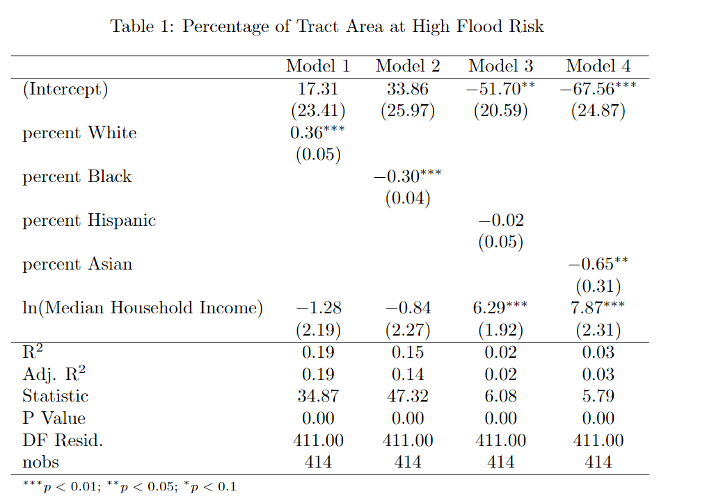

The coefficients of the “percent [Ethnicity]” variables indicate the average percentage point difference in the high-risk area of a given tract for a one percentage point increase in the amount of the tract’s total population that ethnicity makes up while holding median household income constant. E.g., in Model 1 the 0.36 coefficient for percent White means that on average a tract with a one percentage point higher share of its total population being white had 0.36 percentage points more of its area at high flood risk when median household income was controlled for. The coefficient of the ln(Median Household Income) variable indicates the average percentage point difference in the high-risk area of a given tract for a 1% increase in median household income.

The our second model, we use a linear probability model to see if tract median household income and ethnicity predict weather or not a tract will have more than 13% of its area covered by high risk flood zones. We choose 13% because of the tracts that have high risk flood zone this is the median point. We also run this model with with a different outcome variable. Where 23% of the tract area covered by high risk zones will turn on the binary variable. By changing the outcome variable we do not find different results. As in the first model we do not use all ethnicities in a regression to avoid colinearity issues. Our results for the linear probability model are shown in Table 2

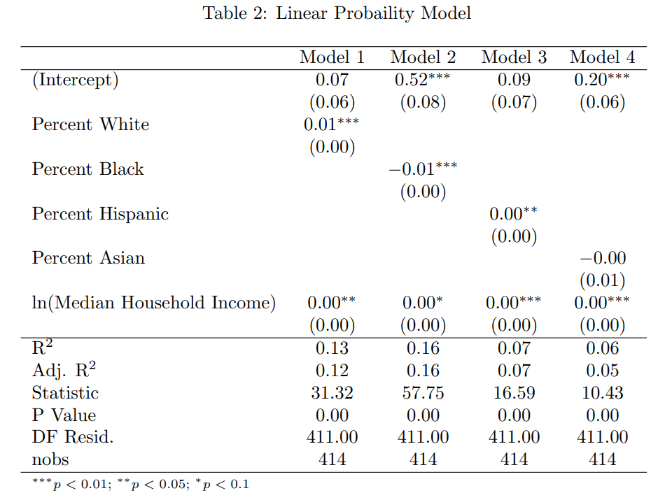

### Results

From Models 1 and 2 of Table 1, we can see that the coefficient for percent White is positive and highly statistically significant, and the coefficient for percent Black is negative and highly statistically significant. On average, a tract with a one percentage point higher share of its total population being white had 0.36 percentage points more of its area at high flood risk when median household income was controlled for. On average, a tract with a one percentage point higher share of its total population being black had 0.30 percentage points less of its area at high flood risk when median household income was controlled for. This aligns well with our previous findings; we observe disproportionately high flood risk for the white population of the county and disproportionately low risk for the black population. In both cases, the coefficient of ln(Median Household Income) is negative, but statistically insignificant, aligning with our lack of finding a clear relationship between tract-level median household income and flood risk in Broward County. Interestingly, in Models 3 and 4 of Table 1, this same coefficient is positive and statistically significant, but looking at the incredibly low R-squared value and the lower significance of the demographic controls, we suspect this is not suggestive of a real-world relationship.

In the linear probability model, for each regression we find that all else equal, a 1% increase in median household income is associated on average with a 0 percentage point change in the probability of being in one the tracts with more than 13% of the area covered by high risk zones.In the first regression we find that all else equal, a 1% increase in the white population of a tract is associated on average with a 1 percentage point increase in the probability of being in a tract with more than 13% high risk flood zones. Similarly in the second regression, we find that all else equal, a 1% increase in the black population of a tract is associated on average with a 1 percentage point decrease in the probability of being in a tract with more than 13% high risk flood zones. These results are consistent with our first OLS model and the bar charts uses to display the disproportionate impacts of flood risk.